# Auditing the Capability-Gap Model

- Show All Code
- Hide All Code
- View Source

How it is built · what its axes measure · how the SHAP need-profile is filtered and aggregated · how to read the gap analysis honestly

Author

Net Zero Industrial Policy Lab (NZIPL) · Johns Hopkins SAIS

Published

July 3, 2026

```r
library(readr); library(dplyr); library(tidyr); library(tibble); library(arrow)
library(ggplot2); library(patchwork); library(knitr); library(kableExtra); library(showtext)
font_add_google("Archivo", "Archivo"); showtext_auto(); showtext_opts(dpi = 200)

NZ_DARK <- "#073309"; NZ_GREEN <- "#3cb54a"; NZ_LIGHT <- "#f0f7f0"
theme_nr <- function(...) theme_minimal(base_family = "Archivo", base_size = 12) +
  theme(plot.title = element_text(size = 14, face = "bold", colour = NZ_DARK),
        plot.subtitle = element_text(size = 11, colour = "#475569"),
        panel.grid.minor = element_blank(), ...)
theme_set(theme_nr())

CATS <- c("Chemicals","Electronics","Industrial Materials","Machinery","Metals")
feat <- read_csv(here::here("data/pc/pc_features.csv"), show_col_types = FALSE)
rca  <- read_parquet(here::here("data/pc/pc_rca.parquet"))
gd   <- read_csv(here::here("data/green_dict/green_dictionary.csv"), show_col_types = FALSE)
YR   <- max(rca$year, na.rm = TRUE)

# The two aggregations of the "need" axis, per tech × cluster.
agg <- feat |> filter(category %in% CATS) |>
  group_by(tech, category) |>
  summarise(s = sum(shap_mean_z), m = mean(shap_mean_z), n = n(), .groups = "drop") |>
  group_by(tech) |>
  mutate(pct_sum = s / sum(s) * 100,     # handbook: SUM of member importances
         pct_mean = m / sum(m) * 100) |>  # MEAN across members (magnitude-preserving)
  ungroup()
rc <- rca |> filter(category %in% CATS, year == YR) |> select(iso3, country, tech, category, rca)

classify <- function(sp, r) dplyr::case_when(
  sp>=25 & r>=1 ~ "Leverage",  sp>=25 & r>=.5 ~ "Build-up", sp>=25 ~ "Critical gap",
  sp>=10 & r>=1 ~ "Mature",    sp>=10 & r>=.5 ~ "Build-up", sp>=10 ~ "Gap",
  r>=1 ~ "Bonus", TRUE ~ "Not priority")
CELLCOL <- c(Leverage="#22c55e","Build-up"="#f97316","Critical gap"="#ef4444",
             Mature="#86efac", Gap="#f59e0b", Bonus="#38bdf8","Not priority"="#94a3b8")
cellord <- c("Leverage","Build-up","Critical gap","Mature","Gap","Bonus","Not priority")
NOTABLE <- c("BRA","IND","MEX","JPN","VNM","ESP","KOR","USA","CHN","DEU","CAN")

# 3-way feature bucket: supply-chain input (value-chain) / co-export neighbour / macro
pad6 <- function(x){ x <- suppressWarnings(as.integer(x)); ifelse(is.na(x), NA, sprintf("%06d", x)) }
gd_codes <- gd |> transmute(tech, code6 = pad6(code)) |> filter(!is.na(code6)) |> distinct() |> mutate(sc = TRUE)
feat_b <- feat |> mutate(code6 = ifelse(is.na(hs_code), NA, pad6(hs_code))) |>
  left_join(gd_codes, by = c("tech","code6")) |>
  mutate(bucket = case_when(category == "Non-HS" ~ "macro / policy",
                            !is.na(sc)            ~ "supply-chain input",
                            TRUE                  ~ "co-export neighbour"))

# --- sample-case radar machinery (always 5 axes; absent cluster = "no data") ---
prep_case <- function(iso_, tech_) {
  tibble(category = CATS) |>
    left_join(rc  |> filter(iso3 == iso_, tech == tech_) |> select(category, rca), by = "category") |>
    left_join(agg |> filter(tech == tech_) |> select(category, pct_sum, pct_mean, n), by = "category") |>
    mutate(present   = !is.na(pct_sum),
           cell_sum  = ifelse(present, classify(pct_sum,  rca), NA_character_),
           cell_mean = ifelse(present, classify(pct_mean, rca), NA_character_),
           category  = factor(category, levels = CATS)) |>
    arrange(category)
}
radar_plot <- function(d, which = c("sum","mean")) {
  which <- match.arg(which)
  pct  <- if (which == "sum") d$pct_sum  else d$pct_mean
  cell <- if (which == "sum") d$cell_sum else d$cell_mean
  base <- tibble(category = as.character(d$category),
                 shap_r = pmin(coalesce(pct, 0) / 50, 1),
                 rca_r  = pmin(coalesce(d$rca, 0) / 1.5, 1), cell = cell)
  n <- nrow(base); ang <- pi/2 - 2*pi*(seq_len(n) - 1)/n
  mk <- function(r, s) tibble(series = s, x = r*cos(ang), y = r*sin(ang))
  poly <- bind_rows(mk(base$shap_r, "SHAP need (aggregated)"), mk(base$rca_r, "Country RCA (have)"))
  grid <- tidyr::expand_grid(ring = c(0.25,0.5,0.75,1), i = seq_len(n)) |>
    mutate(a = pi/2 - 2*pi*(i - 1)/n, x = ring*cos(a), y = ring*sin(a))
  spokes <- tibble(x = cos(ang), y = sin(ang))
  labs_df <- base |> mutate(x = 1.36*cos(ang), y = 1.36*sin(ang),
                            celltxt = ifelse(is.na(cell), "no data", cell),
                            labcol = ifelse(is.na(cell), "#aab2b8", CELLCOL[cell]),
                            lab = paste0(category, "\n[", celltxt, "]"))
  ggplot() +
    geom_polygon(data = grid, aes(x, y, group = ring), fill = NA, colour = "grey86", linewidth = 0.3) +
    geom_segment(data = spokes, aes(x = 0, y = 0, xend = x, yend = y), colour = "grey86", linewidth = 0.3) +
    geom_polygon(data = poly, aes(x, y, group = series, fill = series, colour = series), alpha = 0.35, linewidth = 0.8) +
    geom_text(data = labs_df, aes(x, y, label = lab), family = "Archivo", fontface = "bold", size = 2.5,
              lineheight = 0.9, colour = labs_df$labcol) +
    scale_fill_manual(values = c("SHAP need (aggregated)"="#eab308","Country RCA (have)"="#3cb54a"), name=NULL) +
    scale_colour_manual(values = c("SHAP need (aggregated)"="#eab308","Country RCA (have)"="#3cb54a"), name=NULL) +
    coord_equal(xlim = c(-1.65,1.65), ylim = c(-1.5,1.5), clip = "off") +
    labs(title = if (which == "sum") "SUM aggregation (handbook axis)" else "MEAN aggregation") +
    theme_void(base_family = "Archivo") +
    theme(legend.position = "bottom", plot.title = element_text(size = 11, face = "bold", hjust = 0.5, colour = "#334155"))
}
case_panel <- function(iso_, tech_, title) {
  d <- prep_case(iso_, tech_)
  (radar_plot(d, "sum") | radar_plot(d, "mean")) +
    plot_annotation(title = title, theme = theme(plot.title = element_text(family="Archivo", face="bold", size=15, colour="#073309"))) +
    plot_layout(guides = "collect") & theme(legend.position = "bottom")
}
flip_table <- function(iso_, tech_) {
  prep_case(iso_, tech_) |>
    transmute(Category = as.character(category), RCA = round(rca, 2),
              `SHAP% (sum)` = round(pct_sum, 1), `Cell (sum)` = coalesce(cell_sum, "no data"),
              `SHAP% (mean)` = round(pct_mean, 1), `Cell (mean)` = coalesce(cell_mean, "no data"),
              Δ = ifelse(!is.na(cell_sum) & !is.na(cell_mean) & cell_sum != cell_mean, "→ moves", "")) |>
    arrange(desc(coalesce(`SHAP% (sum)`, -1)))
}
```

**Purpose.** A single, consolidated audit of the SHAP–RCA “capability-gap” model that underlies the *Atlas of the Clean Industrial Base* radar and the 3×3 gap grid. It covers (i) how the model is built and what its two outputs are, (ii) the **feature-selection filtering** the model uses and how the Atlas **restricts it into a “standard tech profile” of what is needed**, (iii) what the “need” axis actually measures, (iv) how sensitive the classification is to the sum-vs-mean aggregation, and (v) whether the design is circular. Every figure recomputes live from the shipped data (`data/pc/`, `data/green_dict/`), and the **model design was verified against Ishana Ratan’s source notebooks** (`~/Documents/R/CICE/ML_vars/`, a clone of `github.com/ishanaratan/CICE`). This is **not** a claim that the model is “wrong” — the design is a legitimate input→output one. It is an argument that the **aggregation and presentation of the SHAP need-profile** are undocumented and materially change the conclusions. Reference year **2024**.

# 1 Executive summary

1. **Two outputs, often conflated.** The Random Forest emits a **Predicted Competitiveness score** (a probability, per country) *and* **SHAP importances** (which the Atlas turns into the radar’s “need” axis). They are different objects linked by an exact identity — the SHAP values *decompose* the score — but only the aggregated, absolute-valued, thresholded SHAP ships. Formulas in Section 2.1.
2. **The need-profile is a feature-selection artifact, repurposed.** The model’s `|SHAP| → z-score → average → keep |z| ≥ 0.5` pipeline is a legitimate, principled **feature-selection** step (Cohen’s *d* moderate-effect cut) whose job is to answer *“which capabilities clear a moderate-effect bar?”*. The Atlas then **sums the survivors by category** into a *quantitative* “need” axis — a role the selection output was not built for (Section 3).
3. **So the “need” axis is mostly a product count.** Summing cluster members makes the axis ≈99.9% correlated with *how many product codes the dictionary put in the cluster*; it inflates dispersion ~8×; switching to a **mean** flips the top driver for 9 of 11 techs (Section 4).
4. **The classification is aggregation-dependent.** Across 8228 country×tech×cluster cases, **~56%** change cell between sum and mean; two cells become unreachable under mean (Section 6).
5. **The largest predictors are hidden.** Macro features (GDP, FDI, manufacturing) are ~14% of importance and rank #1 for Solar — but are dropped from the radar (Section 4).
6. **The gap analysis is *not* circular (verified against source).** The target is the RCA of the **final product** (e.g. Solar = HS 854140), the target codes are **excluded from the features**, and the features are **lagged one year**. A genuine input→output design; the “60% supply-chain” share is the model correctly using the value chain, not circularity (Section 7). *(An earlier draft argued the opposite; reading the code corrected it.)*

**Net:** a sound, non-circular design, whose SHAP need-profile is filtered sensibly but then **aggregated and presented in ways that mislead** — count-driven, unsigned, country-averaged, macro-hidden.

# 2 How the model is built

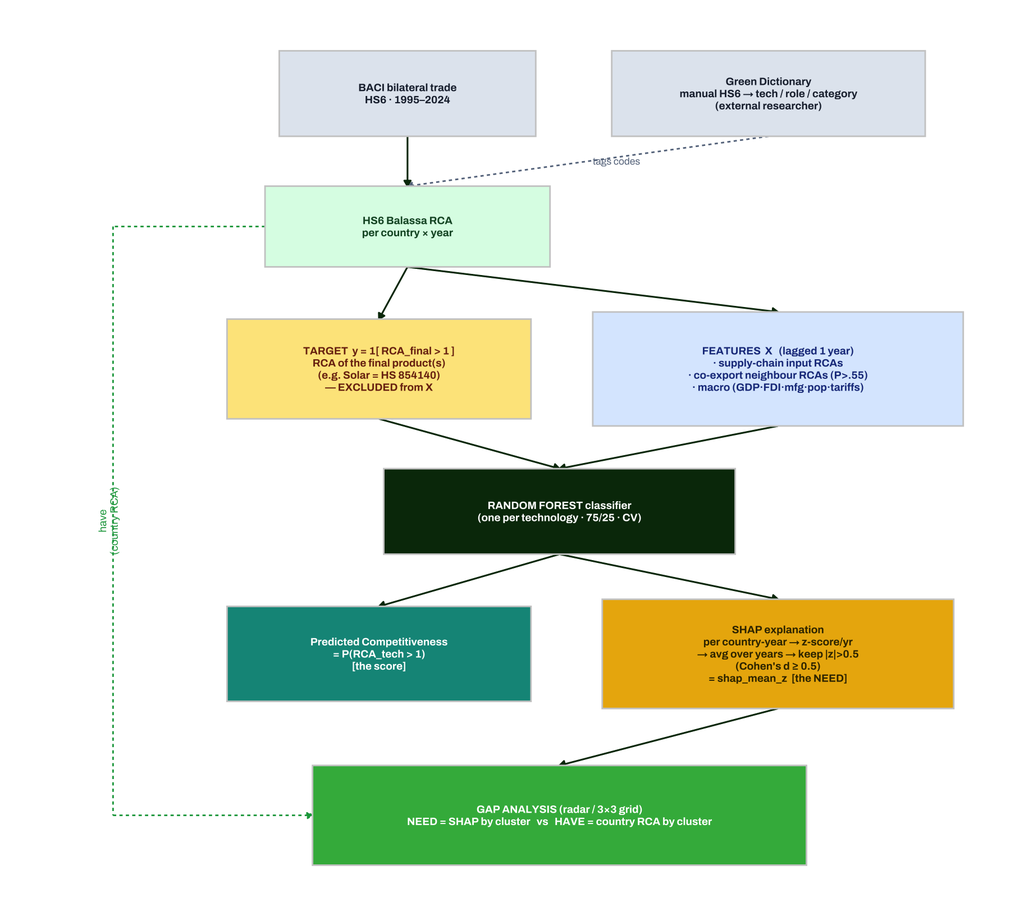

End-to-end construction (verified against Ishana’s notebooks). The RF has two outputs (score and SHAP). The TARGET is a final-product RCA that is EXCLUDED from the features, and the features are lagged one year — an input→output design, not a circular one (see the circularity section).

```r
B <- tribble(
  ~id,~cx,~cy,~w,~h,~fill,~tx,~label,
  "baci",2.2,6.0,2.7,.9,"#e2e8f0","#1e293b","BACI bilateral trade\nHS6 · 1995–2024",
  "dict",6.0,6.0,3.3,.9,"#e2e8f0","#1e293b","Green Dictionary\nmanual HS6 → tech / role / category\n(external researcher)",
  "rca",2.2,4.6,3.0,.85,"#dcfce7","#14532d","HS6 Balassa RCA\nper country × year",
  "target",1.9,3.1,3.2,1.05,"#fde68a","#7c2d12","TARGET  y = 1[ RCA_final > 1 ]\nRCA of the final product(s)\n(e.g. Solar = HS 854140)\n— EXCLUDED from X",
  "feat",6.1,3.1,3.9,1.2,"#dbeafe","#1e3a8a","FEATURES  X   (lagged 1 year)\n· supply-chain input RCAs\n· co-export neighbour RCAs (P>.55)\n· macro (GDP·FDI·mfg·pop·tariffs)",
  "rf",3.8,1.6,3.7,.9,NZ_DARK,"white","RANDOM FOREST classifier\n(one per technology · 75/25 · CV)",
  "pc",1.9,0.1,3.2,1.0,"#0d9488","white","Predicted Competitiveness\n= P(RCA_tech > 1)\n[the score]",
  "shap",6.1,0.1,3.7,1.15,"#eab308","#3b2f00","SHAP explanation\nper country-year → z-score/yr\n→ avg over years → keep |z|>0.5\n(Cohen's d ≥ 0.5)\n= shap_mean_z  [the NEED]",
  "gap",3.8,-1.6,5.2,1.05,"#3cb54a","white","GAP ANALYSIS (radar / 3×3 grid)\nNEED = SHAP by cluster   vs   HAVE = country RCA by cluster"
) |> mutate(xmin=cx-w/2,xmax=cx+w/2,ymin=cy-h/2,ymax=cy+h/2)
g <- function(i) B[B$id==i,]
va <- function(f,t,dash=FALSE) tibble(x=g(f)$cx,y=g(f)$ymin,xend=g(t)$cx,yend=g(t)$ymax,dash=dash)
E <- bind_rows(va("baci","rca"),va("dict","rca",TRUE),va("rca","target"),va("rca","feat"),
               va("target","rf"),va("feat","rf"),va("rf","pc"),va("rf","shap"),va("shap","gap"))
mx <- -0.9
have <- tibble(x=c(g("rca")$xmin,mx,mx),y=c(g("rca")$cy,g("rca")$cy,g("gap")$cy),
               xend=c(mx,mx,g("gap")$xmin),yend=c(g("rca")$cy,g("gap")$cy,g("gap")$cy))
ggplot()+
  geom_segment(data=filter(E,!dash),aes(x,y,xend=xend,yend=yend),arrow=arrow(length=unit(.15,"cm"),type="closed"),colour=NZ_DARK,linewidth=.55)+
  geom_segment(data=filter(E,dash),aes(x,y,xend=xend,yend=yend),arrow=arrow(length=unit(.15,"cm"),type="closed"),colour="#64748b",linewidth=.5,linetype="22")+
  geom_segment(data=have[1:2,],aes(x,y,xend=xend,yend=yend),colour="#16a34a",linewidth=.5,linetype="22")+
  geom_segment(data=have[3,],aes(x,y,xend=xend,yend=yend),arrow=arrow(length=unit(.15,"cm"),type="closed"),colour="#16a34a",linewidth=.5,linetype="22")+
  annotate("text",x=mx-0.05,y=(g("rca")$cy+g("gap")$cy)/2,label="have\n(country RCA)",angle=90,family="Archivo",size=2.5,colour="#16a34a",lineheight=.9)+
  annotate("text",x=(g("dict")$cx+g("rca")$cx)/2+.3,y=(g("dict")$ymin+g("rca")$ymax)/2,label="tags codes",family="Archivo",size=2.3,colour="#64748b")+
  geom_rect(data=B,aes(xmin=xmin,xmax=xmax,ymin=ymin,ymax=ymax,fill=fill),colour="grey80")+
  geom_text(data=B,aes(cx,cy,label=label,colour=tx),family="Archivo",fontface="bold",size=2.5,lineheight=.95)+
  scale_fill_identity()+scale_colour_identity()+coord_equal(xlim=c(-1.6,8.2),clip="off")+theme_void()
```

**In words.** Trade flows (BACI) plus a manual HS6→tech classification (the **Green Dictionary**, built by an external researcher) give an HS6 Balassa RCA per country-year. That splits into a **target** — is the country a revealed specialist in the *final product*, `RCA_final > 1`? — and a **feature vector** of *other* product RCAs plus co-export neighbours plus macro covariates, lagged one year. A Random Forest (one per technology) learns the target from the features.

## 2.1 The two outputs, precisely

The RF produces two distinct things that are easy to conflate. For a country-year with feature vector $x$, the forest of $T$ trees returns a probability that the country is competitive:

$$\hat p(x) \;=\; \widehat{P}\big(\text{RCA}_{\text{final}} > 1 \mid x\big) \;=\; \frac{1}{T}\sum_{t=1}^{T} h_t(x) \;\in\; [0,1].$$

This scalar **is** the Predicted Competitiveness score. SHAP does not produce a second prediction — it **explains that same $\hat p(x)$** by splitting it into signed per-feature contributions that obey an exact additive identity:

$$\hat p(x) \;=\; \phi_0 + \sum_{j=1}^{M}\phi_j(x), \qquad\Longleftrightarrow\qquad \sum_{j=1}^{M}\phi_j(x) = \hat p(x) - \phi_0,$$

where $\phi_0$ is the baseline (average output) and $\phi_j(x)$ is the signed push feature $j$ gives this prediction. **Both statements hold at once, and there is no contradiction:** the score is a *scalar*; the SHAP values are a *length-$M$ signed vector* that decomposes it. So the Predicted Competitiveness score is **not** “the sum of the SHAP weights” — the SHAP values sum to the prediction *minus baseline*, per observation, and are signed.

|  | **Predicted Competitiveness (score)** | **SHAP weights** |
| --- | --- | --- |
| Answers | *How* competitive is this country? | *Why* — which features drove it? |
| What it is | probability $\hat p(x)=P(\text{RCA}>1)$ | per-feature attribution $\phi_j(x)$ of that probability |
| Granularity (raw) | one per country × tech × year | one per country × tech × year × feature |
| Signed? | — | **raw SHAP is signed** (+ toward / − away) |
| In the shipped data | `pc_scores` | `shap_mean_z` = **\|SHAP\|**, z-scored, **averaged over years and countries**, thresholded → one per tech × feature |

The gap-analysis radar uses the `shap_mean_z` summary; it never uses the score. How that summary is built — and what it discards — is Section 3.

## 2.2 What a “feature” is

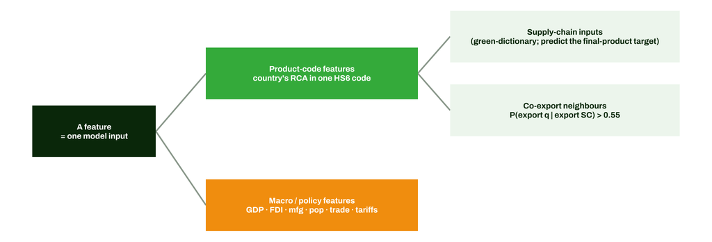

Two kinds of feature. Most are product-code features (a country’s RCA in one HS6 code), split into supply-chain products and co-export neighbours; a smaller block is macro / policy covariates.

```r
bx <- tribble(
  ~id,~cx,~cy,~w,~fill,~txt,~label,
  "root",1.0,3.0,2.1,NZ_DARK,"white","A feature\n= one model input",
  "prod",4.7,4.1,3.6,NZ_GREEN,"white","Product-code features\ncountry's RCA in one HS6 code",
  "macro",4.7,1.6,3.6,"#f59e0b","white","Macro / policy features\nGDP · FDI · mfg · pop · trade · tariffs",
  "sc",9.0,4.8,3.9,NZ_LIGHT,NZ_DARK,"Supply-chain inputs\n(green-dictionary; predict the final-product target)",
  "coex",9.0,3.4,3.9,NZ_LIGHT,NZ_DARK,"Co-export neighbours\nP(export q | export SC) > 0.55"
) |> mutate(h=0.98,xmin=cx-w/2,xmax=cx+w/2,ymin=cy-h/2,ymax=cy+h/2)
edg <- tribble(~from,~to,"root","prod","root","macro","prod","sc","prod","coex") |>
  left_join(select(bx,from=id,fx=xmax,fy=cy),by="from") |>
  left_join(select(bx,to=id,tx=xmin,ty=cy),by="to")
ggplot()+
  geom_segment(data=edg,aes(fx,fy,xend=tx,yend=ty),colour="#9aa79c",linewidth=.7)+
  geom_rect(data=bx,aes(xmin=xmin,xmax=xmax,ymin=ymin,ymax=ymax,fill=fill),colour=NA)+
  geom_text(data=bx,aes(cx,cy,label=label,colour=txt),family="Archivo",fontface="bold",size=2.85,lineheight=.95)+
  scale_fill_identity()+scale_colour_identity()+coord_cartesian(clip="off")+theme_void()
```

This split — **supply-chain vs co-export vs macro** — is the hinge of the whole audit; it returns in the circularity check (Section 7).

# 3 Feature selection and the “standard tech profile”

This section is the crux of the audit and the part most relevant to the model’s authors: it separates what the model *legitimately does* (select features) from what the Atlas *does with the result* (build a quantitative, country-invariant “standard tech profile” of what a technology needs).

## 3.1 The model’s selection step is principled

For each technology the pipeline turns the raw per-feature SHAP into a retained feature list in four steps (verified in `~/Documents/R/CICE/ML_vars/Analysis/RCA <Tech> Analysis.ipynb`):

1. **Global importance** — average absolute SHAP over the $N$ country-years: $\;I_j = \tfrac{1}{N}\sum_i |\phi_j(x_i)|$.
2. **Year-specific standardization** — within each year, z-score each feature’s SHAP across countries; average $|z|$ over countries and years: $\;\bar z_j = \tfrac{1}{N}\sum_i |z_{ij}|,\quad z_{ij}=\tfrac{\phi_{ij}-\bar\phi_j}{\sigma_j}$.
3. **Cohen’s-*d* selection** — retain $j \iff \bar z_j \ge 0.5$ (Cohen: 0.2 small / 0.5 medium / 0.8 large; the cut keeps *at least moderate* standardized importance). This is the `shap_mean_z` that ships, and the methods appendix documents exactly this — a **list** of retained features per tech (its SI Tables 21–30).
4. **Category aggregation** *(Atlas-side, not in the appendix)* — sum the retained importances within each of the five SHAP categories: $\;S_c = \sum_{j\in c,\ \bar z_j\ge 0.5}\bar z_j$.

Steps 1–3 are a standard, defensible feature-selection procedure. **The whole audit is about step 4** and how the Atlas reads its output.

## 3.2 What the z-score does to the numbers

The z-score does two things to each feature’s SHAP: it **centers** it and — the important one — **divides it by its own standard deviation**. That division rescales every feature to the *same spread*, which **removes the magnitude**. Two features in one year, across a handful of countries:

| Feature | raw $\|\text{SHAP}\|$ across countries | raw mean$\|\text{SHAP}\|$ |
| --- | --- | --- |
| **Feature A** (swings predictions a lot) | 0.40, 0.20, 0.08, 0.02, 0.01 | ≈ **0.14** |
| **Feature B** (barely matters) | 0.04, 0.02, 0.008, 0.002, 0.001 | ≈ **0.014** |

On the **raw** scale A is ~**10× more important** than B. Now z-score each feature (divide by its own SD): both distributions are squeezed to spread 1, so:

|  | after z-score, mean$\|z\|$ |
| --- | --- |
| **Feature A** | ≈ **0.8** |
| **Feature B** | ≈ **0.8** |

They come out **nearly identical**. The z-score divided out the very thing that made A more important than B. This is not a bug — it is what standardization *is for*: the appendix’s stated rationale is to put features on a comparable scale **across technologies** with different class balance, so one threshold applies uniformly. The consequence, though, is that **once features clear the bar their standardized importances are nearly interchangeable** — which is what makes the category sum in step 4 behave like a count (Section 4).

## 3.3 From selected features to a “standard tech profile”

Here is precisely how NZIPL *restricts* the model output to build the Atlas need-profile:

- **Restriction 1 — drop the below-threshold tail.** Only features with $\bar z_j \ge 0.5$ enter. (Reasonable.)
- **Restriction 2 — drop the macro block from the radar.** Only the five *traded* SHAP categories (Chemicals, Electronics, Industrial Materials, Machinery, Metals) become axes; GDP/FDI/manufacturing/tariffs — often the single most important feature — are set aside (Section 4).
- **Restriction 3 — collapse to one profile per technology.** The retained features are summed within category *across all countries* — `shap_mean_z` is already averaged over country-years — producing **one country-invariant 5-axis profile per tech**. This is the “**standard tech profile** of what is needed”: a canonical statement of *“to be competitive in technology $T$, these capability clusters matter, in these proportions.”*

The design intent of a *standard* profile is defensible — a technology’s capability requirements are, to first order, a property of the technology, not the country, so a single per-tech “what is needed” template is a reasonable object. **The problem is the axis that template is drawn on.** Because of the z-score (magnitude gone) and the sum (step 4), the proportions on that standard profile are driven by *how many product codes the dictionary assigned to each cluster*, not by how much each cluster actually moves competitiveness. The country enters only through the green “have” (RCA) overlay; the gold “need” template is the same for every country.

## 3.4 What the restriction keeps and discards

| Step | What it keeps | What it discards |
| --- | --- | --- |
| **z-score** ($\div$ own SD) | relative position within a feature | **magnitude** — which capability matters *more* |
| **$\lvert\cdot\rvert$ absolute value** | strength | **direction** — helps vs. hurts |
| **mean over countries** | a common per-tech profile (“standard”) | **country-specificity** |
| **Cohen’s-*d* > 0.5 cut** | the set of moderate+ features (meaningful!) | the below-threshold tail |
| **drop macro from radar** | a clean 5-cluster picture | the top-ranked non-value-chain predictors |
| **sum by category** | a per-cluster total | reduces to a **count** (magnitude already gone) |

So what **survives** is real and useful: *the set of capabilities the model found at least moderately important for each tech.* What is **lost** — for a *need-vs-have* tool — is the ordering among them (z-score), the sign (absolute value), the country dimension (averaging), and the macro block (radar restriction); and then the category sum turns the survivors into a headcount.

**One-sentence takeaway.** Rather than *“they manipulated SHAP and lost information,”* the fair statement is: **a principled feature-selection output was repurposed as a quantitative importance axis, and the standardization / absolute-value / averaging / sum strip out exactly the magnitude, direction, and country-specificity that a “need-vs-have” gap analysis depends on.** The standard tech profile reads as if it ranks capability importance, but mostly it counts selected products.

# 4 The “need” axis is mostly a product count

Three facts show that summing `shap_mean_z` over a cluster’s members makes the axis track *cluster size*, not model-learned importance.

First, the raw picture: per-feature importances *do* vary, but the five **cluster means are nearly identical** — a direct consequence of the principled Cohen’s-*d* cut, which retains a homogeneous moderate-to-strong band (≈0.50–0.82), so every cluster mean lands in its middle.

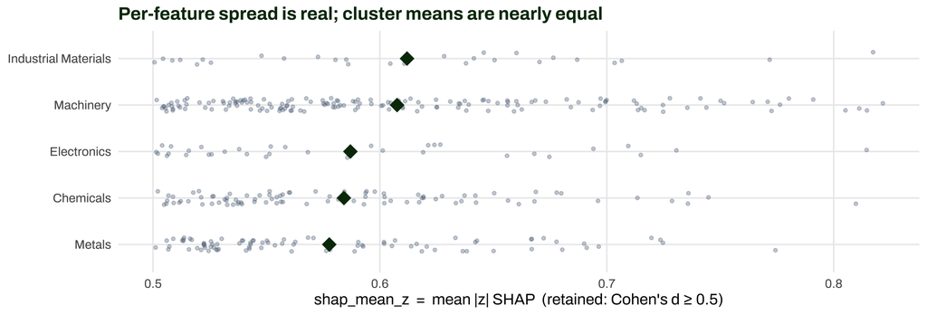

Distribution of retained importance by cluster (points) with cluster means (diamonds). Real feature-to-feature spread, but the five cluster means sit within ~0.03 — because the Cohen’s-d cut keeps a homogeneous set. Since the means cannot separate the clusters, only the product COUNTS can — which is what the sum does.

```r
fc <- feat |> filter(category %in% CATS)
ggplot(fc, aes(reorder(category, shap_mean_z), shap_mean_z)) +
  geom_jitter(width = .15, alpha = .35, colour = "#64748b", size = 1) +
  stat_summary(fun = mean, geom = "point", shape = 18, size = 5, colour = NZ_DARK) +
  coord_flip() +
  labs(x = NULL, y = "shap_mean_z  =  mean |z| SHAP  (retained: Cohen's d ≥ 0.5)",
       title = "Per-feature spread is real; cluster means are nearly equal")
```

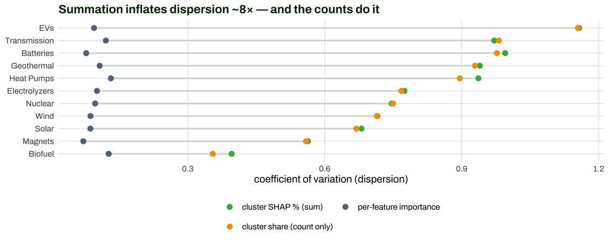

Per-feature importances are nearly flat (grey, CV~0.10). Summing them into cluster shares inflates dispersion ~8× (green) — and that sits almost exactly on the count-only share (orange). The spread that makes the axis look ‘decisive’ is produced by counting.

```r
cv <- function(x) sd(x)/mean(x)
d_feat <- fc |> group_by(tech) |> summarise(`per-feature importance` = cv(shap_mean_z), .groups="drop")
d_cat  <- fc |> group_by(tech,category) |> summarise(s=sum(shap_mean_z), n=n(), .groups="drop") |>
  group_by(tech) |> summarise(`cluster SHAP % (sum)` = cv(s/sum(s)),
                              `cluster share (count only)` = cv(n/sum(n)), .groups="drop")
disp <- left_join(d_feat,d_cat,by="tech") |> pivot_longer(-tech, names_to="stage", values_to="cv")
ggplot(disp, aes(cv, reorder(tech, cv))) +
  geom_line(aes(group=tech), colour="#d5dbd5", linewidth=.9) +
  geom_point(aes(colour=stage), size=2.6) +
  scale_colour_manual(values=c("per-feature importance"="#64748b",
    "cluster SHAP % (sum)"=NZ_GREEN,"cluster share (count only)"="#f59e0b"), name=NULL) +
  labs(x="coefficient of variation (dispersion)", y=NULL,
       title="Summation inflates dispersion ~8× — and the counts do it") +
  theme(legend.position="bottom") + guides(colour=guide_legend(nrow=2))
```

```r
shp <- fc |> group_by(tech,category) |> summarise(s=sum(shap_mean_z), m=mean(shap_mean_z), n=n(), .groups="drop") |>
  group_by(tech) |> mutate(pct_sum=s/sum(s)*100, pct_mean=m/sum(m)*100, pct_cnt=n/sum(n)*100) |> ungroup()
n_flip <- shp |> group_by(tech) |> summarise(f = category[which.max(pct_sum)] != category[which.max(pct_mean)]) |> pull(f) |> sum()
tibble(comparison = c("SHAP% (sum) vs product-count %","SHAP% (sum) vs SHAP% (mean-based)"),
       correlation = c(round(cor(shp$pct_sum, shp$pct_cnt),3), round(cor(shp$pct_sum, shp$pct_mean),3))) |>
  kable(caption = sprintf("The 'need' axis is 99.9%% the feature count and nearly unrelated to the magnitude-based reading. Aggregating by mean instead of sum flips the top driver for %d of 11 techs.", n_flip))
```

The ‘need’ axis is 99.9% the feature count and nearly unrelated to the magnitude-based reading. Aggregating by mean instead of sum flips the top driver for 9 of 11 techs.

| comparison | correlation |
| --- | --- |
| SHAP% (sum) vs product-count % | 0.999 |
| SHAP% (sum) vs SHAP% (mean-based) | 0.243 |

**The largest predictors are dropped.** The radar shows only the five traded clusters, but the macro block often holds the single most important feature:

```r
feat |> group_by(tech) |>
  mutate(rk = rank(-shap_mean_z)) |>
  summarise(`best macro rank` = suppressWarnings(min(rk[category=="Non-HS"])),
            `macro % of importance` = round(sum(shap_mean_z[category=="Non-HS"])/sum(shap_mean_z)*100),
            .groups="drop") |> filter(is.finite(`best macro rank`)) |> arrange(`best macro rank`) |>
  kable(caption = "For Solar the #1 feature overall is FDI; macro is ~14% of importance on average — all invisible on the radar.")
```

For Solar the #1 feature overall is FDI; macro is ~14% of importance on average — all invisible on the radar.

| tech | best macro rank | macro % of importance |
| --- | --- | --- |
| Solar | 1 | 16 |
| Nuclear | 2 | 13 |
| Electrolyzers | 3 | 11 |
| Biofuel | 4 | 8 |
| Magnets | 5 | 26 |
| Heat Pumps | 6 | 19 |
| Wind | 7 | 7 |
| Batteries | 12 | 14 |
| Geothermal | 13 | 4 |
| Transmission | 13 | 19 |

**Confirmed from source — see the companion `ml_replication.qmd`.** That note regenerates this need axis from Ishana’s notebooks for **all 11 technologies** (RFs pinned, seed 28) and finds, from scratch: the shipped cluster axis correlates **r ≈ 0.99** with product count; the **top-priority cluster flips for 9 of 11 techs** once magnitude is preserved; ~**47%** of retained features are **net-negative** (the sign the axis discards); and each feature’s country-year `|SHAP|` has a median peak **~17× its own mean** (the country variation the average collapses). Solar reproduces the shipped `shap_mean_z` **bit-for-bit**, confirming the pipeline is replicated exactly.

# 5 Sum vs mean, and the sample cases

Neither aggregation is “true”: **sum** answers *“where is the tech’s model-relevant footprint concentrated?”* (breadth, dominated by cluster size); **mean** answers *“how important is a typical product here?”* (depth, nearly flat). Because the quadrant’s SHAP thresholds (10%, 25%) are fixed, that reshaping pushes clusters across cell boundaries. The three sample cases make it concrete — the gold “need” polygon changes, the green “have” (RCA) polygon does not, and axis labels are coloured by the cell each cluster lands in *under that aggregation*.

```r
cases <- tribble(~iso, ~tech, ~title,
  "IND","Solar",     "India · Solar",
  "BRA","Biofuel",   "Brazil · Biofuel",
  "CAN","Batteries", "Canada · Batteries")
cases |>
  mutate(`clusters that move cell` = purrr::map2_int(iso, tech, function(i, t) {
           p <- prep_case(i, t)
           sum(!is.na(p$cell_sum) & !is.na(p$cell_mean) & p$cell_sum != p$cell_mean) }),
         `clusters with data` = purrr::map2_int(iso, tech, ~sum(prep_case(.x, .y)$present))) |>
  transmute(Case = title, `clusters with data`, `clusters that move cell`) |>
  kable(caption = "How many capability clusters change their quadrant cell when the aggregation switches from sum to mean.")
```

How many capability clusters change their quadrant cell when the aggregation switches from sum to mean.

| Case | clusters with data | clusters that move cell |
| --- | --- | --- |
| India · Solar | 5 | 2 |
| Brazil · Biofuel | 4 | 0 |
| Canada · Batteries | 5 | 3 |

## 5.1 India · Solar

The flagship. Under **sum**, Chemicals is a **Critical gap** (the single top priority); under **mean** it is only a **Gap**, and low-count Industrial Materials rises from *Not priority* to *Gap*. The “deep upstream” headline is partly an artifact of counting chemistry products.

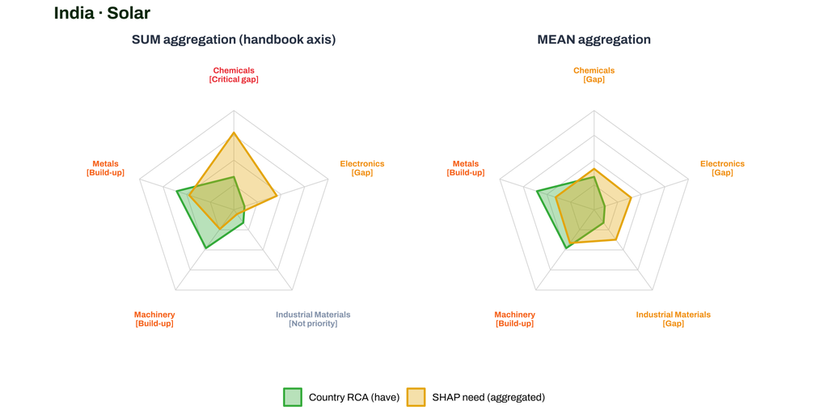

```r
case_panel("IND", "Solar", "India · Solar")
```

```r
kable(flip_table("IND", "Solar"), caption = "India · Solar — the top-priority cell (Chemicals) is aggregation-dependent.")
```

India · Solar — the top-priority cell (Chemicals) is aggregation-dependent.

| Category | RCA | SHAP% (sum) | Cell (sum) | SHAP% (mean) | Cell (mean) | Δ |
| --- | --- | --- | --- | --- | --- | --- |
| Chemicals | 0.50 | 38.9 | Critical gap | 20.6 | Gap | → moves |
| Metals | 0.91 | 23.7 | Build-up | 20.4 | Build-up |  |
| Electronics | 0.17 | 22.7 | Gap | 19.6 | Gap |  |
| Machinery | 0.72 | 12.0 | Build-up | 20.7 | Build-up |  |
| Industrial Materials | 0.24 | 2.7 | Not priority | 18.6 | Gap | → moves |

## 5.2 Brazil · Biofuel

No cell *changes*, but the dispersion point is vivid: the **sum** polygon is spiky (Machinery/Chemicals dominate) while the **mean** rounds out across the clusters biofuel touches (all ≈22–26%). **Electronics** shows as *no data*: no electronics HS codes map to biofuel, so the model retains no electronics feature — an honest gap, not a zero.

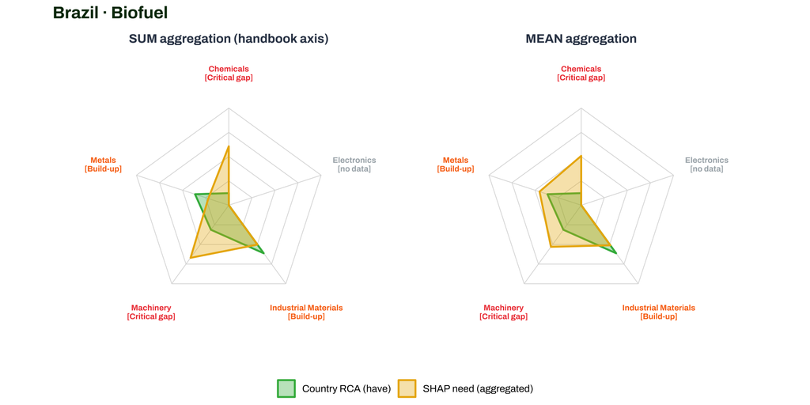

```r
case_panel("BRA", "Biofuel", "Brazil · Biofuel")
```

```r
kable(flip_table("BRA", "Biofuel"), caption = "Brazil · Biofuel — cells are stable, but the SHAP% profile flattens dramatically under mean.")
```

Brazil · Biofuel — cells are stable, but the SHAP% profile flattens dramatically under mean.

| Category | RCA | SHAP% (sum) | Cell (sum) | SHAP% (mean) | Cell (mean) | Δ |
| --- | --- | --- | --- | --- | --- | --- |
| Machinery | 0.47 | 33.5 | Critical gap | 26.5 | Critical gap |  |
| Chemicals | 0.19 | 30.3 | Critical gap | 25.4 | Critical gap |  |
| Industrial Materials | 0.92 | 25.1 | Build-up | 25.5 | Build-up |  |
| Metals | 0.55 | 11.1 | Build-up | 22.6 | Build-up |  |
| Electronics | NA | NA | no data | NA | no data |  |

## 5.3 Canada · Batteries

The most volatile. Under **sum**, only Chemicals and Machinery clear the 10% bar; everything else is *Not priority*. Under **mean**, the three low-count clusters (Metals, Electronics, Industrial Materials) all clear 10% and become **Gap** — turning a two-priority picture into a five-priority one.

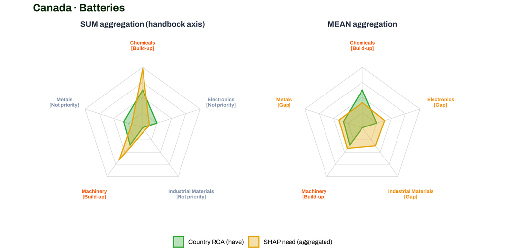

```r
case_panel("CAN", "Batteries", "Canada · Batteries")
```

```r
kable(flip_table("CAN", "Batteries"), caption = "Canada · Batteries — three clusters cross Not-priority → Gap purely from the aggregation switch.")
```

Canada · Batteries — three clusters cross Not-priority → Gap purely from the aggregation switch.

| Category | RCA | SHAP% (sum) | Cell (sum) | SHAP% (mean) | Cell (mean) | Δ |
| --- | --- | --- | --- | --- | --- | --- |
| Chemicals | 0.94 | 48.6 | Build-up | 20.8 | Build-up |  |
| Machinery | 0.53 | 32.9 | Build-up | 21.1 | Build-up |  |
| Metals | 0.49 | 9.5 | Not priority | 20.3 | Gap | → moves |
| Electronics | 0.37 | 6.0 | Not priority | 19.3 | Gap | → moves |
| Industrial Materials | 0.00 | 2.9 | Not priority | 18.4 | Gap | → moves |

## 5.4 All eleven technologies: the standard need-profile, both ways

Stripping out the country dimension, this is the pure “need” question for every technology — the **standard tech profile** from Section 3: gold = the handbook’s **sum** profile, teal = the **mean** profile, on a shared per-tech scale. Across all eleven the pattern is identical — **sum spikes toward the fat clusters, mean rounds toward a regular pentagon.** Clusters marked `*` are *no data*.

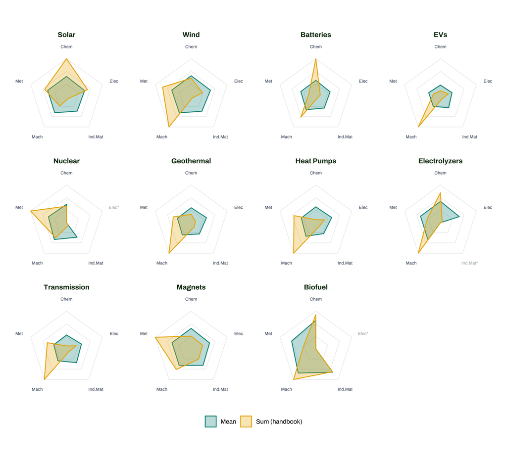

SHAP-only standard need profile per technology: gold = sum (handbook), teal = mean. The mean profile is a near-regular pentagon almost everywhere — once you divide out the counts, the model sees each cluster as roughly equally important. All the inter-cluster structure in the handbook radar is count structure.

```r
ABBR <- c(Chemicals="Chem",Electronics="Elec","Industrial Materials"="Ind.Mat",Machinery="Mach",Metals="Met")
tech_radar <- function(tech_) {
  b <- tibble(category=CATS) |> left_join(agg|>filter(tech==tech_)|>select(category,pct_sum,pct_mean),by="category")
  denom <- max(c(b$pct_sum,b$pct_mean),na.rm=TRUE)
  b <- b |> mutate(sum_r=coalesce(pct_sum,0)/denom,mean_r=coalesce(pct_mean,0)/denom,present=!is.na(pct_sum))
  n<-nrow(b); ang<-pi/2-2*pi*(seq_len(n)-1)/n
  mk<-function(r,s) tibble(series=s,x=r*cos(ang),y=r*sin(ang))
  poly<-bind_rows(mk(b$sum_r,"Sum (handbook)"),mk(b$mean_r,"Mean"))
  grid<-tidyr::expand_grid(ring=c(.33,.66,1),i=seq_len(n))|>mutate(a=pi/2-2*pi*(i-1)/n,x=ring*cos(a),y=ring*sin(a))
  lab<-b|>mutate(x=1.32*cos(ang),y=1.32*sin(ang),lab=ifelse(present,ABBR[category],paste0(ABBR[category],"*")),col=ifelse(present,"#475569","#aab2b8"))
  ggplot()+geom_polygon(data=grid,aes(x,y,group=ring),fill=NA,colour="grey88",linewidth=.22)+
    geom_polygon(data=poly,aes(x,y,group=series,fill=series,colour=series),alpha=.30,linewidth=.6)+
    geom_text(data=lab,aes(x,y,label=lab),family="Archivo",size=2.2,colour=lab$col)+
    scale_fill_manual(values=c("Sum (handbook)"="#eab308","Mean"="#0d9488"),name=NULL)+
    scale_colour_manual(values=c("Sum (handbook)"="#eab308","Mean"="#0d9488"),name=NULL)+
    coord_equal(xlim=c(-1.5,1.5),ylim=c(-1.4,1.4),clip="off")+labs(title=tech_)+
    theme_void(base_family="Archivo")+theme(plot.title=element_text(size=10,face="bold",hjust=.5,colour=NZ_DARK),legend.position="bottom")
}
techs11<-c("Solar","Wind","Batteries","EVs","Nuclear","Geothermal","Heat Pumps","Electrolyzers","Transmission","Magnets","Biofuel")
patchwork::wrap_plots(lapply(techs11,tech_radar),ncol=4)+patchwork::plot_layout(guides="collect") & theme(legend.position="bottom")
```

# 6 Population EDA — does the classification abide?

Applying the 7-cell scheme to **all** country×tech×cluster cases stress-tests whether the grid is exhaustive-and-populated and whether it is *stable* to the aggregation choice.

```r
pop <- rc |> inner_join(agg, by=c("tech","category")) |>
  mutate(cell_sum=classify(pct_sum,rca), cell_mean=classify(pct_mean,rca))
chg <- mean(pop$cell_sum != pop$cell_mean)
```

The population is **8228** observations across **226** economies. Every observation is classified **both ways** so the difference is explicit.

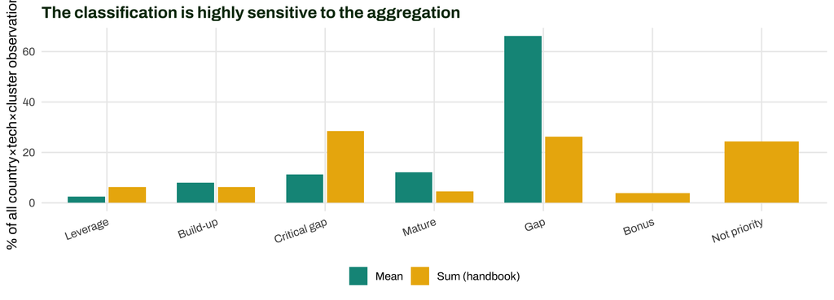

Share of all observations in each cell, sum vs mean. Under mean the two low-SHAP cells (Bonus, Not-priority) empty out entirely and Gap balloons to ~66%.

```r
dd <- bind_rows(pop|>count(cell=cell_sum)|>mutate(agg="Sum (handbook)"),
                pop|>count(cell=cell_mean)|>mutate(agg="Mean")) |>
  mutate(cell=factor(cell,levels=cellord), pct=n/nrow(pop)*100)
ggplot(dd, aes(cell, pct, fill=agg)) +
  geom_col(position=position_dodge(width=.75), width=.68) +
  scale_fill_manual(values=c("Sum (handbook)"="#eab308","Mean"="#0d9488"), name=NULL) +
  labs(x=NULL, y="% of all country×tech×cluster observations",
       title="The classification is highly sensitive to the aggregation") +
  theme(legend.position="bottom", axis.text.x=element_text(angle=20,hjust=1))
```

Under mean the two low-SHAP cells empty out (mean never falls below 10%, so **Bonus and Not-priority are structurally unreachable**) and Gap swells from ~26% to ~66%. The scheme’s *reachable* cells depend on the aggregation — a sign the thresholds are calibrated to the sum’s inflated dispersion.

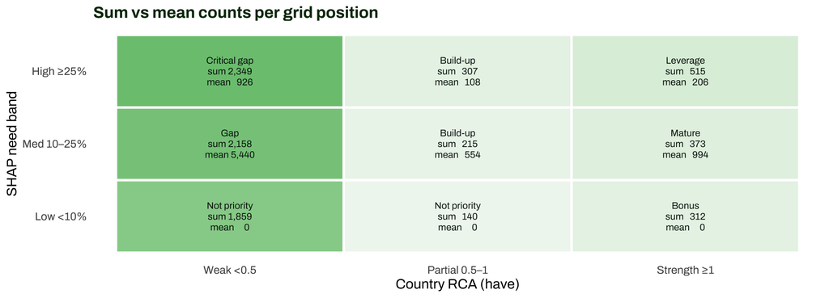

Each tile shows the count under both aggregations; tile colour follows the sum count. All nine positions are used under sum; the whole Low-SHAP row is empty under mean.

```r
SL<-c("Low <10%","Med 10–25%","High ≥25%"); RL<-c("Weak <0.5","Partial 0.5–1","Strength ≥1")
b1<-function(v)cut(v,c(-1,10,25,1e9),labels=SL); b2<-function(v)cut(v,c(-1,.5,1,1e9),labels=RL)
gsum<-pop|>count(SHAP=b1(pct_sum),RCA=b2(rca),name="n_sum"); gmean<-pop|>count(SHAP=b1(pct_mean),RCA=b2(rca),name="n_mean")
nm<-c("High ≥25%.Strength ≥1"="Leverage","High ≥25%.Partial 0.5–1"="Build-up","High ≥25%.Weak <0.5"="Critical gap",
      "Med 10–25%.Strength ≥1"="Mature","Med 10–25%.Partial 0.5–1"="Build-up","Med 10–25%.Weak <0.5"="Gap",
      "Low <10%.Strength ≥1"="Bonus","Low <10%.Partial 0.5–1"="Not priority","Low <10%.Weak <0.5"="Not priority")
gd2<-tidyr::expand_grid(SHAP=factor(SL,SL),RCA=factor(RL,RL))|>left_join(gsum,by=c("SHAP","RCA"))|>left_join(gmean,by=c("SHAP","RCA"))|>
  mutate(across(c(n_sum,n_mean),~replace_na(.,0L)),cellname=nm[paste(SHAP,RCA,sep=".")])
ggplot(gd2,aes(RCA,SHAP,fill=n_sum))+geom_tile(colour="white",linewidth=1)+
  geom_text(aes(label=sprintf("%s\nsum %s\nmean %s",cellname,format(n_sum,big.mark=","),format(n_mean,big.mark=","))),family="Archivo",size=2.9,lineheight=.95,colour="#0b1a12")+
  scale_fill_gradient(low="#f0f7f0",high="#7bc47f",guide="none")+
  labs(x="Country RCA (have)",y="SHAP need band",title="Sum vs mean counts per grid position")+theme(panel.grid=element_blank())
```

Overall **56% of cases change cell** between the two aggregations — the classification is a *framing*, not a stable rule. The heavy Weak-RCA (left-column) concentration is *expected*: RCA>1 is a relative measure, so most country-cluster pairs are genuinely “weak”; the instability is on the SHAP axis, not the RCA axis.

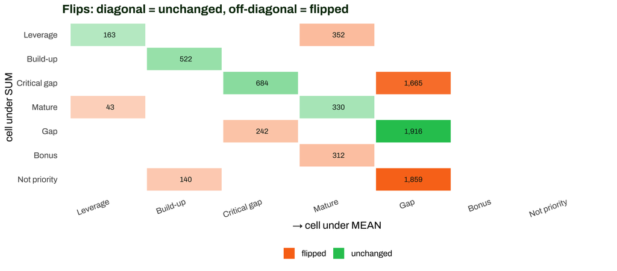

Both axes use the same 7-cell order, so the DIAGONAL (green) is cases whose cell is unchanged and every OFF-diagonal (orange) tile is a flip. The two rightmost columns (Bonus, Not-priority) are empty — mean never produces them. Opacity ∝ count.

```r
tm <- pop |> count(cell_sum, cell_mean) |>
  mutate(cell_sum  = factor(cell_sum,  levels = rev(cellord)),
         cell_mean = factor(cell_mean, levels = cellord),
         moved = ifelse(as.character(cell_sum) == as.character(cell_mean), "unchanged", "flipped"))
ggplot(tm, aes(cell_mean, cell_sum)) +
  geom_tile(aes(fill = moved, alpha = n), colour = "white", linewidth = 0.9) +
  geom_text(aes(label = format(n, big.mark = ",")), family = "Archivo", size = 3, colour = "#0b1a12") +
  scale_fill_manual(values = c(unchanged = "#22c55e", flipped = "#f97316"), name = NULL) +
  scale_alpha(range = c(0.30, 1), guide = "none") +
  scale_x_discrete(drop = FALSE) + scale_y_discrete(drop = FALSE) +
  labs(x = "→ cell under MEAN", y = "cell under SUM",
       title = "Flips: diagonal = unchanged, off-diagonal = flipped") +
  theme(panel.grid = element_blank(), axis.text.x = element_text(angle = 20, hjust = 1), legend.position = "bottom")
```

The flips are systematic, not noisy: mean compresses the SHAP axis into the middle band, so the two largest moves are **Not-priority → Gap** and **Critical gap → Gap**, and the strong-RCA cells slide **Leverage → Mature** and **Bonus → Mature**. Only ~44% sit on the diagonal. Whether a case is a *top priority* (Critical gap / Leverage) or a *middling* one (Gap / Mature) is, for most of the population, a choice of aggregation.

Concrete examples (notable economies, cases selected by their **sum** cell, top by RCA within it). The **Sum cell** and **Mean cell** columns sit side by side; rows are shaded **green where they agree** and **orange where the classification flips**:

```r
cell_examples <- function(cl, n = 5) {
  pop |> filter(iso3 %in% NOTABLE, cell_sum == cl) |> arrange(desc(rca)) |> slice_head(n = n) |>
    transmute(Country = country, Technology = tech, Cluster = as.character(category),
              RCA = round(rca, 2), `SHAP% (sum)` = round(pct_sum, 1),
              `Sum cell` = cl, `Mean cell` = cell_mean)
}
extab <- bind_rows(lapply(c("Leverage","Build-up","Critical gap","Mature","Bonus"), cell_examples))
same <- which(extab$`Sum cell` == extab$`Mean cell`); diff <- setdiff(seq_len(nrow(extab)), same)
if (knitr::is_html_output()) {
  kbl(extab, caption = "Representative cases per sum-cell, with the cell each lands in under mean. Green = unchanged, orange = flipped.") |>
    kable_styling(full_width = FALSE, font_size = 12, bootstrap_options = c("condensed")) |>
    column_spec(6:7, border_left = TRUE) |>
    row_spec(same, background = "#e8f7ee") |> row_spec(diff, background = "#fdecdf")
} else {
  extab |> mutate(` ` = ifelse(`Sum cell` == `Mean cell`, "= unchanged", "→ flipped")) |>
    kable(caption = "Representative cases per sum-cell, with the cell each lands in under mean (last column flags unchanged vs flipped).")
}
```

Representative cases per sum-cell, with the cell each lands in under mean. Green = unchanged, orange = flipped.

| Country | Technology | Cluster | RCA | SHAP% (sum) | Sum cell | Mean cell |
| --- | --- | --- | --- | --- | --- | --- |
| Brazil | Nuclear | Metals | 7.88 | 49.6 | Leverage | Leverage |
| Brazil | Transmission | Metals | 7.57 | 27.0 | Leverage | Mature |
| Brazil | Geothermal | Metals | 7.56 | 25.2 | Leverage | Mature |
| Canada | Biofuel | Industrial Materials | 5.05 | 25.1 | Leverage | Leverage |
| Japan | Transmission | Machinery | 4.67 | 50.6 | Leverage | Mature |
| United States | Electrolyzers | Machinery | 1.00 | 45.4 | Build-up | Build-up |
| United States | Heat Pumps | Machinery | 0.99 | 48.4 | Build-up | Build-up |
| India | Geothermal | Chemicals | 0.98 | 11.2 | Build-up | Build-up |
| Canada | Electrolyzers | Machinery | 0.98 | 45.4 | Build-up | Build-up |
| Germany | Solar | Metals | 0.97 | 23.7 | Build-up | Build-up |
| India | Electrolyzers | Chemicals | 0.50 | 35.9 | Critical gap | Critical gap |
| India | Solar | Chemicals | 0.50 | 38.9 | Critical gap | Gap |
| Mexico | Transmission | Metals | 0.49 | 27.0 | Critical gap | Gap |
| Vietnam | Heat Pumps | Metals | 0.49 | 29.4 | Critical gap | Gap |
| India | Nuclear | Metals | 0.49 | 49.6 | Critical gap | Critical gap |
| Brazil | EVs | Metals | 10.98 | 11.9 | Mature | Mature |
| Canada | Nuclear | Chemicals | 5.71 | 21.7 | Mature | Mature |
| Japan | Magnets | Industrial Materials | 3.51 | 12.5 | Mature | Mature |
| South Korea | Magnets | Industrial Materials | 3.38 | 12.5 | Mature | Mature |
| South Korea | Magnets | Chemicals | 3.07 | 12.7 | Mature | Mature |
| Brazil | Heat Pumps | Chemicals | 11.71 | 3.8 | Bonus | Mature |
| Brazil | Transmission | Chemicals | 11.71 | 4.0 | Bonus | Mature |
| Japan | EVs | Industrial Materials | 4.67 | 4.5 | Bonus | Mature |
| Canada | Transmission | Industrial Materials | 3.47 | 4.9 | Bonus | Mature |
| South Korea | EVs | Industrial Materials | 3.41 | 4.5 | Bonus | Mature |

**Does it abide?** *Partly.* It is **exhaustive and interpretable** (every case classifies; the named cells map onto intuitive postures) but **not stable** (56% flip; two cells vanish under mean) and only **weakly discriminating** at the population level (most of the world is Weak-RCA). One **coherence quirk**: cluster-level RCA is *tech-agnostic*, so Brazil’s high Metals RCA makes it a “Metals **Leverage**” case for *every* metals-weighted technology at once — the “have” side does not distinguish which tech the capability serves. The scheme is a sound **communication device** for case-by-case reasoning, not a stable, technology-specific ranking.

# 7 Is the gap analysis circular? (Checked against source code)

An earlier draft argued the gap analysis was substantially **circular** — that the target was an aggregate of the same supply-chain RCAs used as features. Reading Ishana’s notebooks shows that is **not** how the model is built; the concern is **retracted**.

| Design element | Verified in code |
| --- | --- |
| **Target** | `y = 1[ RCA of the final product > 1 ]` — a single final-product HS code (Solar `dv_854140`; Wind `dv_850231`) or a small final-product aggregate (Batteries `dv_battery` over `{850760, 850780}`). *Not… |
| **Target excluded from X** | `excluded_cols` drops the target column before fitting. Confirmed in the shipped features: 854140, 850231, 850760, 850780 are **all absent** from `pc_features`. |
| **Features** | the *other* products’ RCAs — supply-chain **inputs** + co-export **neighbours** (`prox_codes − supply-chain − target`) + macro. |
| **Temporal lag** | features are `groupby('country_code').shift(1)` — **last-year** capabilities predict **this-year** competitiveness. |
| **SHAP → need** | `\|SHAP\|`, z-scored within year, **mean over country-years**, threshold `mean\|z\| ≥ 0.5` (Cohen’s *d* ≥ 0.5), then category need = `.sum()`. |

So the model predicts *this-year final-product competitiveness* from *last-year upstream + neighbour + macro capabilities*, with the target removed from the inputs — a genuine **input→output** design, **not circular**. The three-way feature split is a *fact*, but its meaning is **value-chain-internal inputs vs external co-export neighbours vs macro**:

```r
feat_b |> group_by(bucket) |>
  summarise(features = n(), `importance mass` = round(sum(shap_mean_z)), .groups="drop") |>
  mutate(`% of features` = round(features/sum(features)*100),
         `% of importance` = round(`importance mass`/sum(`importance mass`)*100)) |>
  arrange(desc(`% of importance`)) |> select(bucket, features, `% of features`, `% of importance`) |>
  kable(caption = "Three-way split of the features. ~60% are the tech's own value-chain inputs, ~30% co-export neighbours, ~10% macro. The model *using the value chain* to predict final-product competitiveness — not circularity.")
```

Three-way split of the features. ~60% are the tech’s own value-chain inputs, ~30% co-export neighbours, ~10% macro. The model *using the value chain* to predict final-product competitiveness — not circularity.

| bucket | features | % of features | % of importance |
| --- | --- | --- | --- |
| supply-chain input | 271 | 60 | 60 |
| co-export neighbour | 139 | 31 | 30 |
| macro / policy | 45 | 10 | 10 |

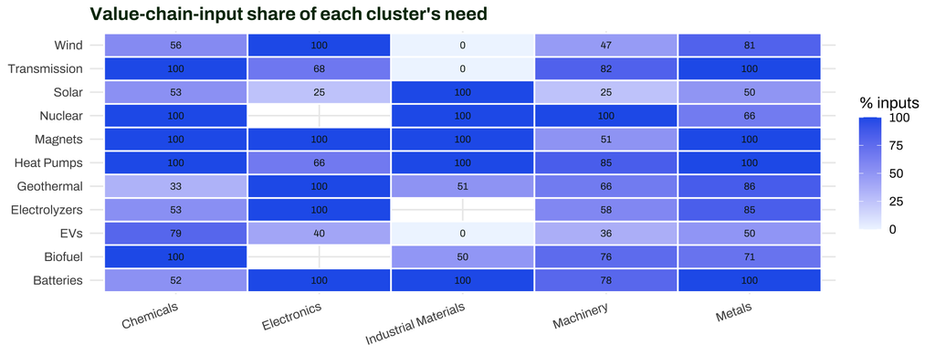

Share of each cluster’s need coming from the tech’s own value-chain inputs (vs co-export neighbours). Descriptive of value-chain structure, not a circularity flag.

```r
sp <- feat_b |> filter(category %in% CATS) |>
  group_by(tech, category) |>
  summarise(need = sum(shap_mean_z), need_in = sum(shap_mean_z[bucket=="supply-chain input"]), .groups="drop") |>
  mutate(in_share = need_in/need*100)
ggplot(sp, aes(factor(category, CATS), tech, fill = in_share)) +
  geom_tile(colour = "white", linewidth = 0.6) +
  geom_text(aes(label = ifelse(is.na(in_share), "—", paste0(round(in_share)))), family="Archivo", size=2.7, colour="#0b1a12") +
  scale_fill_gradient(low = "#eff6ff", high = "#2563eb", na.value = "grey92", name = "% inputs") +
  labs(x = NULL, y = NULL, title = "Value-chain-input share of each cluster's need") +
  theme(axis.text.x = element_text(angle = 20, hjust = 1))
```

**What retracting circularity leaves standing.** The need-axis findings are untouched and were confirmed line-by-line: category need is a `.sum()` (count-driven); `|SHAP|` is unsigned; the mean over countries makes the profile country-invariant; the Cohen’s-*d* cut yields near-equal cluster magnitudes; macro is dropped from the radar. The RF’s genuine, non-circular contribution — lagged upstream/neighbour/macro capabilities predict final-product competitiveness — is real, but **under-served by the aggregation**.

# 8 How to read the capability map (with the caveats applied)

The 7-cell grid remains a useful *communication device*, provided it is read as diagnostic, not predictive. Read against the India · Solar panels above: under sum, Chemicals is a **Critical gap** (headline priority); under mean, only a **Gap**. The honest reading — given the source check (non-circular) and the need-axis critique (aggregation) — is: *lagged Chemicals-input capability is among the predictors of final-module competitiveness, and India lacks it* — a genuine input→output finding, but whose **cluster ranking is aggregation-dependent** and should be reported as “between cells,” not asserted as the single top priority.

```r
tribble(
  ~Cell, ~`Need (SHAP)`, ~`Have (RCA)`, ~`Read it as`,
  "Leverage","High","Strength","Strength meets need — anchor here (robust where sum & mean agree).",
  "Build-up","High/Med","Partial","One targeted step from competitiveness.",
  "Critical gap","High","Weak","A predictive upstream input the country lacks — a genuine (non-circular) gap, but read the SHAP level with the aggregation caveats.",
  "Mature","Med","Strength","A maintained specialisation; supporting, not decisive.",
  "Gap","Med","Weak","Second-order weakness; sequence after critical gaps.",
  "Bonus","Low","Strength","Capability the tech barely rewards — an asset for another tech (vanishes under mean).",
  "Not priority","Low","Partial/Weak","Low-salience (vanishes under mean)."
) |> kable(caption = "The seven cells, annotated with the audit caveats.")
```

The seven cells, annotated with the audit caveats.

| Cell | Need (SHAP) | Have (RCA) | Read it as |
| --- | --- | --- | --- |
| Leverage | High | Strength | Strength meets need — anchor here (robust where sum & mean agree). |
| Build-up | High/Med | Partial | One targeted step from competitiveness. |
| Critical gap | High | Weak | A predictive upstream input the country lacks — a genuine (non-circular) gap, but read the SHAP level with the aggregation caveats. |
| Mature | Med | Strength | A maintained specialisation; supporting, not decisive. |
| Gap | Med | Weak | Second-order weakness; sequence after critical gaps. |
| Bonus | Low | Strength | Capability the tech barely rewards — an asset for another tech (vanishes under mean). |
| Not priority | Low | Partial/Weak | Low-salience (vanishes under mean). |

# 9 Assessment, verdict and recommendations

**Verdict.** The model’s **design is sound and — verified against source — not circular**: it predicts final-product competitiveness from *lagged* upstream, co-export, and macro capabilities, with the target excluded from the inputs. The feature-selection step (z-score → Cohen’s-*d* cut) is legitimate. The problem is confined to the **downstream restriction and aggregation** that turn the selection output into the Atlas’s *standard tech profile*: summed into product counts, absolute-valued (unsigned), averaged over countries, and shorn of its macro block. The conclusions to revisit are about the *radar and the 3×3 grid*, not the underlying RF.

**Recommendations.**

1. **Fix the need axis, not the model.** Build the category profile from the quantity that still carries magnitude — the **raw `mean|SHAP|`** ($I_j$), aggregated by category — rather than the z-scored, thresholded `shap_mean_z`. Within a single tech the SHAP values are already common-unit (one pooled forest), so no per-feature standardization is needed to compare them, and the raw values preserve the 10:1-type contrasts the z-score erases. Keep the Cohen’s-*d* list as the **selection** step; take **magnitude** from the raw importances. *(Practical note — the raw values are recoverable but not saved: see Section 10.)*
2. **Report NEED as mean as well as sum** (sum ≈ counts), keep the **sign** of SHAP where possible, and **restore the macro block** — it holds top-ranked, non-value-chain predictors.
3. **Document the two outputs** — score vs SHAP; the additive identity $\hat p = \phi_0 + \sum_j \phi_j$; raw-signed vs aggregated-absolute; country-specific vs country-averaged; what can and cannot be summed.
4. **Flag aggregation sensitivity** — cells near a boundary, or that move between sum and mean (~56% of the population), should be read as “between cells,” not asserted. A **sum ⇄ mean toggle** in the Atlas / Report-Builder radar would make the sensitivity visible interactively.
5. **State the design correctly** in any external write-up: single/aggregate **final-product** target, excluded from features, one-year-lagged inputs. Document the category-aggregation rule and the macro exclusion — currently Atlas-only, absent from the methods appendix.

# 10 Reproducibility

Every figure and number recomputes from `data/pc/pc_features.csv`, `data/pc/pc_rca.parquet`, and `data/green_dict/green_dictionary.csv`. Re-render to audit a future model build; the correlations, flip rates, and value-chain-share figures update automatically. The **model design** (targets, exclusions, one-year lag, SHAP aggregation) was verified against Ishana Ratan’s source notebooks under `~/Documents/R/CICE/ML_vars/` (clone of `github.com/ishanaratan/CICE`) — re-check those if the upstream pipeline changes.

**Where the raw SHAP lives (for recommendation 1).** The CICE repo does **not** persist raw SHAP anywhere on disk. In each `ML_vars/Analysis/RCA <Tech> Analysis.ipynb` the fully raw, **signed, per-(country, year, feature)** matrix is built in-memory as the DataFrame `shap_df` (right after `explainer.shap_values(X)` selects the class-1 slice), but it is never written out — the only saved SHAP artifact is the *processed* threshold summary (`|z|`-averaged, `≥0.5`), and that is exported to `/Users/ishanaratan/Desktop/<tech>_hs_shap_above_threshold.csv`, a path **outside the clone**. Everything upstream of SHAP *is* in the repo (the per-tech input RCA CSVs, the in-cell RF training, the `X` construction), so the magnitude-preserving/signed axis is **recoverable by re-running**: execute a notebook and dump `shap_df` (or the raw `mean|SHAP|`) *before* the z-score cell. Caveat: confirm the RF training is seeded/deterministic and the inputs match the shipped build, so the regenerated ranking reproduces the shipped `shap_mean_z` before trusting it. (EV and E-waste compute `shap_df` in-memory but export nothing at all.)

**This has now been done.** `scripts/ml/regen_shap.py` regenerates the raw signed SHAP for all 11 techs from the CICE clone (validated **bit-exact for Solar** against `pc_features`, and 1:1 on the retained HS set for every tech); the artifacts live in `analysis/ml/` (per-tech `raw_signed/` matrices + combined tables). The companion **`ml_replication.qmd`** reports the EDA and confirms, from source, every claim this audit makes about the need axis — that it is count-driven, unsigned, and country-averaged.